# 15. Transformer로 번역기 만들기 [프로젝트]

```python
# Additional Test 3
```

```
Input: 북한 정권의 핵실험은 국제사회의 평화와 자국의 안보를 헤치므로 이를 강하게 규탄한다.
Predicted translation: north koreas regime remains international atomic energy on since the transition of international and security modern competition are fueled by military and peaceful power .
Encoder Layer 1
```

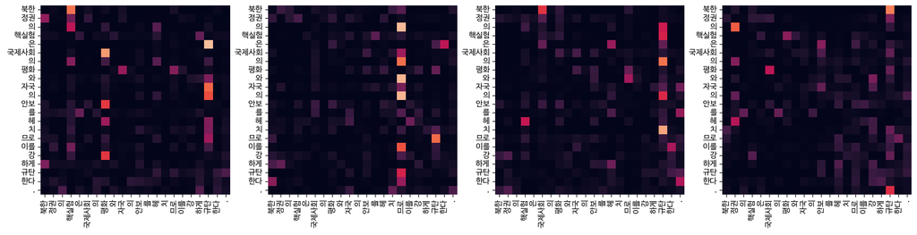

```
Encoder Layer 2
```

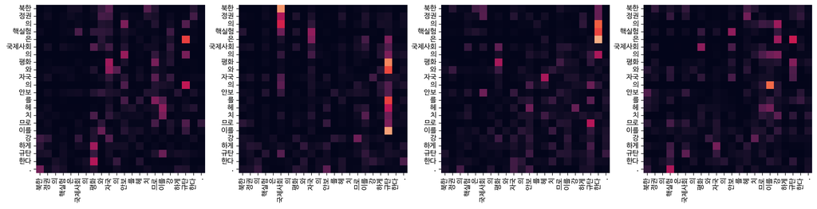

```
Decoder Self Layer 1
```

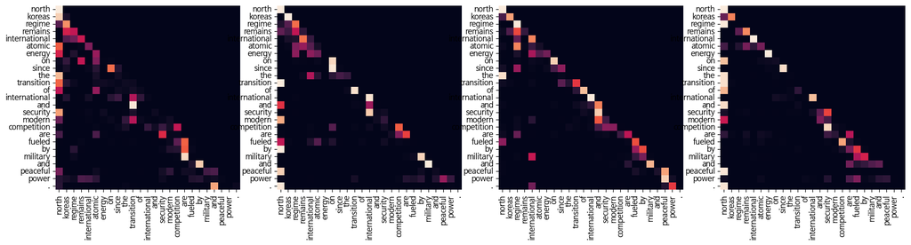

```
Decoder Src Layer 1
```

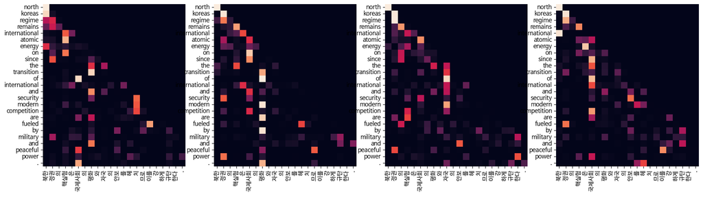

```
Decoder Self Layer 2
```

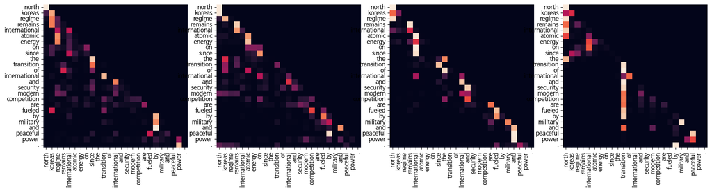

```
Decoder Src Layer 2
```

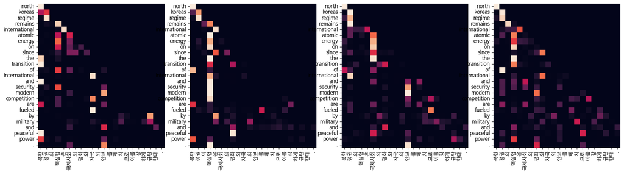

```python
input_text = "북한 정권의 핵실험은 국제사회의 평화와 자국의 안보를 헤치므로 이를 강하게 규탄한다."
custom_translate(input_text)
```

```python
# Additional Test 4
```

```
Input: 국가 안보와 경제 발전은 모두 가장 우선시되야하는 정책들이다.
Predicted translation: economic and political top priority would become the most controversialal issue in the world .
Encoder Layer 1
```

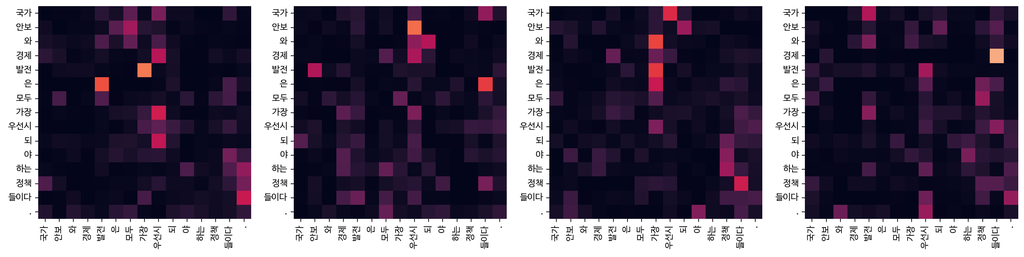

```
Encoder Layer 2
```

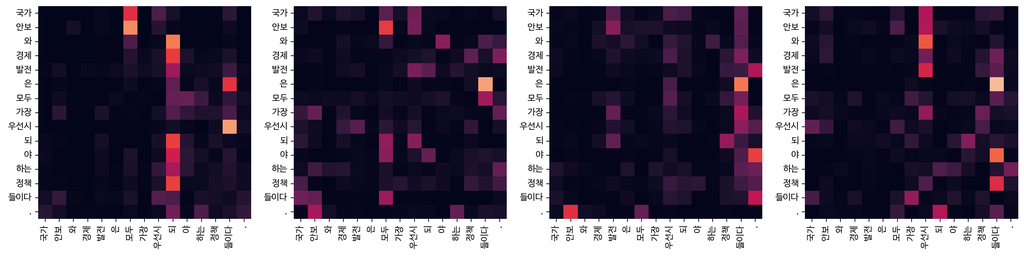

```
Decoder Self Layer 1
```

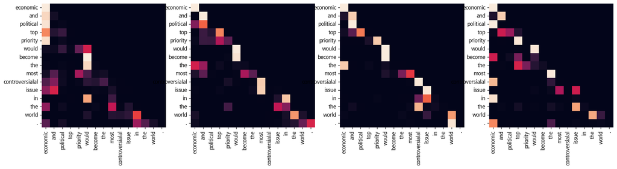

```
Decoder Src Layer 1
```

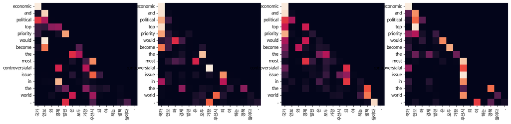

```
Decoder Self Layer 2
```

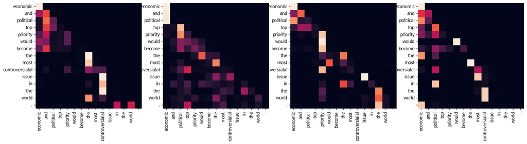

```
Decoder Src Layer 2
```

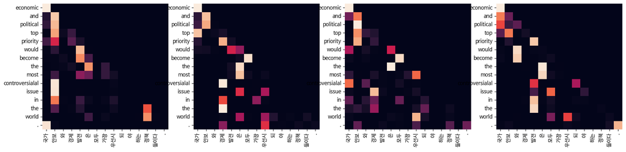

```python
input_text = "국가 안보와 경제 발전은 모두 가장 우선시되야하는 정책들이다."
custom_translate(input_text)
```

```python
# Additional Test 5
```

```
Input: 선거를 통한 지도자의 선출은 민주주의 사회에서의 핵심 원리이다.
Predicted translation: the based through a key process in democracy is the cause of a key influence .
Encoder Layer 1
```

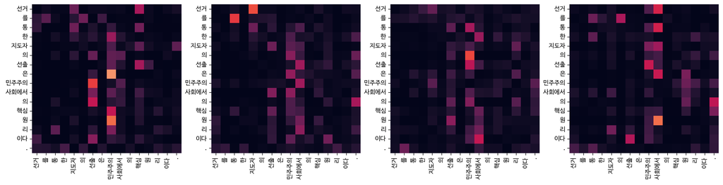

```
Encoder Layer 2
```

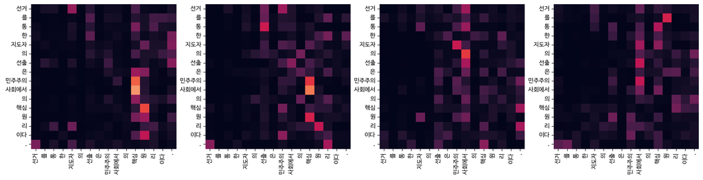

```
Decoder Self Layer 1
```

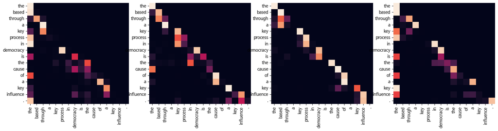

```
Decoder Src Layer 1
```

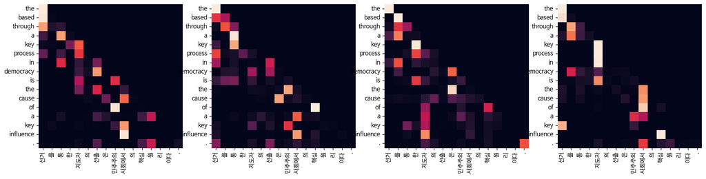

```
Decoder Self Layer 2
```

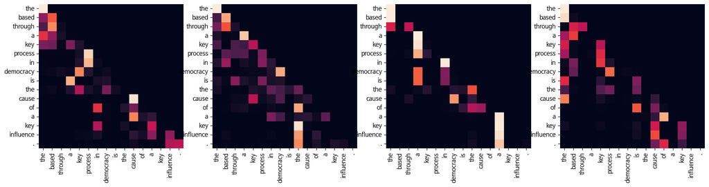

```
Decoder Src Layer 2
```

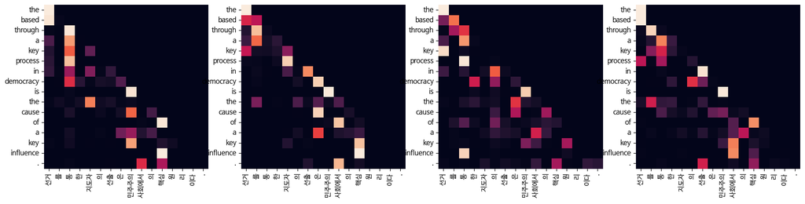

```python
input_text = "선거를 통한 지도자의 선출은 민주주의 사회에서의 핵심 원리이다."
custom_translate(input_text)
```

```python
# Additional Test 6
```

```
Input: 이라크 전쟁에 파병된 장병들의 무사귀한을 기원한다.
Predicted translation: iraq hastened their s stepped forward and is in their calls for soldiers to safely .
Encoder Layer 1
```

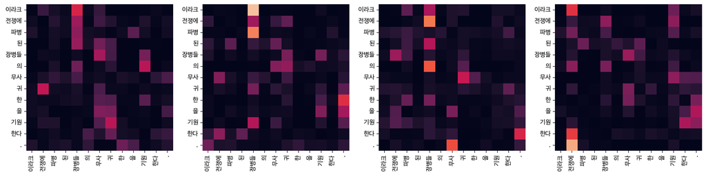

```
Encoder Layer 2
```

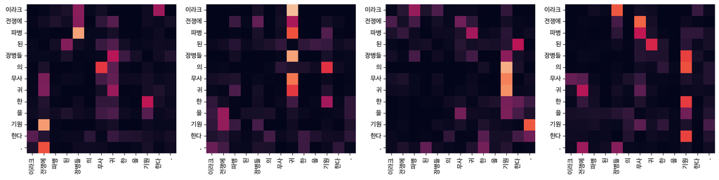

```
Decoder Self Layer 1
```

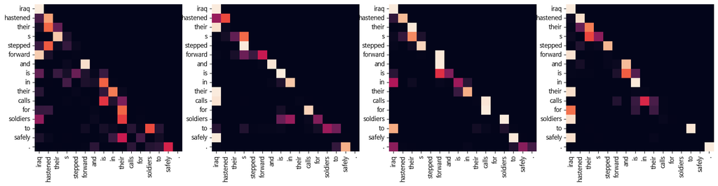

```
Decoder Src Layer 1
```

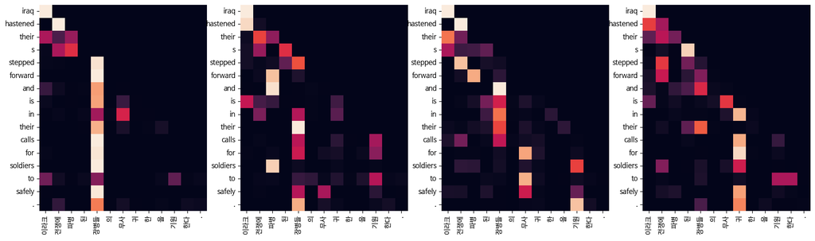

```
Decoder Self Layer 2
```

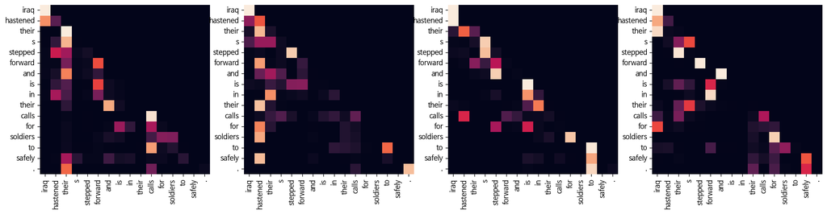

```
Decoder Src Layer 2
```

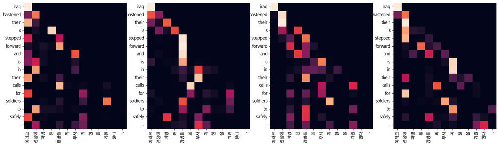

```python
input_text = "이라크 전쟁에 파병된 장병들의 무사귀한을 기원한다."
custom_translate(input_text)
```

## 15-2. 프로젝트 제출

### 루브릭

#### 평가문항 및 상세기준

##### 1. 번역기 모델 학습에 필요한 텍스트 데이터 전처리가 잘 이루어졌다.

데이터 정제, SentencePiece를 활용한 토큰화 및 데이터셋 구축의 과정이 지시대로 진행되었다.

##### 2. Transformer 번역기 모델이 정상적으로 구동된다.

Transformer 모델의 학습과 추론 과정이 정상적으로 진행되어, 한-영 번역기능이 정상 동작한다.

##### 3. 테스트 결과 의미가 통하는 수준의 번역문이 생성되었다.

제시된 문장에 대한 그럴듯한 영어 번역문이 생성되며, 시각화된 Attention Map으로 결과를 뒷받침한다.